# **Visualización de datos en R** Primeros pasos con `ggplot2`

Semillero COBIFMAP · Marta Coronado Zamora

25/10/2026

## 1. Introducción

La **visualización de datos** se refiere a las técnicas que usamos para comunicar datos o información codificándolos como objetos visuales (por ejemplo, puntos, líneas o barras) dentro de **gráficos**. Según [Friedman (2008)](https://www.smashingmagazine.com/2008/01/monday-inspiration-data-visualization-and-infographics/), el objetivo principal de la visualización de datos es **comunicar la información de forma clara** y **eficaz** mediante recursos gráficos.

Según Friedman, esto no significa que una visualización tenga que ser *aburrida* para ser funcional, ni extremadamente sofisticada para ser *bonita*. Para transmitir ideas de forma eficaz, la forma estética y la funcionalidad deben ir de la mano. Sin embargo, a menudo no se consigue el equilibrio entre forma y función, y se crean visualizaciones preciosas que no cumplen su objetivo principal: comunicar información ([Friedman 2008](https://www.smashingmagazine.com/2008/01/monday-inspiration-data-visualization-and-infographics/)).

**Concepto clave**  
Los gráficos son una herramienta excelente para explorar los datos y son imprescindibles para presentar resultados. Su objetivo principal es comunicar información a los usuarios de forma clara y eficiente. Son uno de los pasos del análisis de datos.

Cada nueva visualización puede darnos **pistas** sobre nuestros datos. Parte de esta **información reveladora** puede que ya la conozcamos (aunque quizá todavía no la hayamos demostrado), mientras que otros aspectos pueden ser completamente nuevos. La figura siguiente representa el proceso de búsqueda de nuevas percepciones en los datos ([Aisch 2019](https://interactivos.lanacion.com.ar/manual-data/entender_los_datos_7.html)).

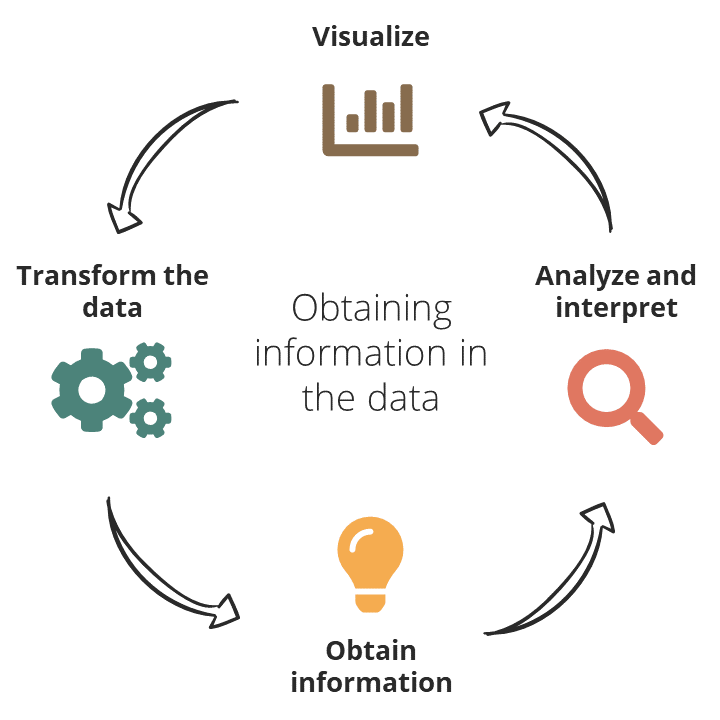

#### Objetivos de aprendizaje

- Aprender la gramática de gráficos de `ggplot2`
- Crear los gráficos más comunes (gráficos de dispersión, de líneas, de barras, histogramas, diagramas de cajas…)
- Distinguir los indicadores de calidad de un gráfico
  - Integridad
  - *Chartjunk*
  - Proporción de tinta de datos
- Conocer las características de una representación gráfica eficaz

### 1.1 Organización de la práctica

En esta práctica vamos a usar [**RStudio**](https://posit.co/products/open-source/rstudio/), un entorno de desarrollo integrado (IDE) para R. R es un lenguaje de programación para el cálculo estadístico y los gráficos.

[figure not shown]

El documento en el que estamos trabajando es un documento **R Markdown**. Los documentos R Markdown son totalmente reproducibles y permiten combinar texto, imágenes y código (en este caso, en lenguaje R).

Para **convertir** (*renderizar*) un documento R Markdown en un archivo HTML, solo tienes que hacer clic en el botón `Knit` de la barra de RStudio. Este archivo HTML se puede compartir como un informe.

No hace falta renderizar todo el documento cada vez que quieras ver el resultado de tu código. Puedes hacer clic en el botón `Run current chunk` (el triángulo verde de cada bloque de código) o usar el atajo de teclado `Ctrl`+`Alt`+`C`, y el resultado del código aparecerá debajo.

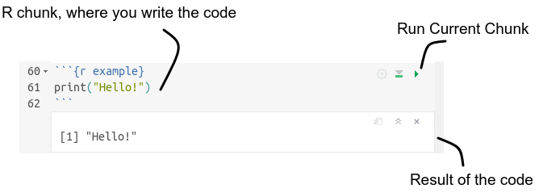

# 2. Instalación de las herramientas

Tienes dos opciones para trabajar con R y RStudio:

- **Instalarlos en tu ordenador** (Windows, macOS o Linux), siguiendo los apartados 2.1 y 2.2.
- **Usar RStudio en la nube** con [Posit Cloud](https://posit.cloud/), sin instalar nada. Solo hay que registrarse (es gratuito), crear un proyecto nuevo (`New Project` > `New RStudio Project`) y subir el archivo `practica-ggplot2.zip` (disponible [aquí](https://marta-coronado.github.io/semillero_COBIFMAP/semillero2/practica/practica-ggplot2.zip)) con el botón `Upload` del panel *Files*. Posit Cloud descomprime el zip automáticamente: tendrás este documento y la carpeta `img` con las imágenes que necesita.

## 2.1 Instalar R

El lenguaje de programación R se puede descargar [aquí](https://cran.rediris.es/) y está disponible para Windows, Linux y macOS.

## 2.2 Instalar RStudio

RStudio se puede descargar [aquí](https://posit.co/download/rstudio-desktop/). Se instala fácilmente en Windows, Linux y macOS. Instala primero R y después RStudio.

## 2.3 Instalar un paquete

Los paquetes de R son colecciones de funciones y/o datos desarrolladas por la comunidad.

Para instalar un paquete, usamos la función `install.packages()`, indicando entre comillas el nombre del paquete que queremos instalar.

### 2.3.1 Instalar `ggplot2`

`ggplot2` es un paquete de visualización de datos para el lenguaje de programación estadística R ([Wickham 2009](https://www.springer.com/gp/book/9780387981413)). Lo creó Hadley Wickham implementando la gramática de gráficos (*Grammar of Graphics*) de Leland Wilkinson, un esquema general para la visualización de datos que divide los gráficos en componentes semánticos ([Wilkinson 2010](https://onlinelibrary.wiley.com/doi/full/10.1002/wics.118)).

Para instalar el paquete `ggplot2`, escribe en la consola:

> `install.packages("ggplot2")`

Solo hace falta instalar un paquete una vez en cada ordenador.

## 2.4 Cargar un paquete

Para cargar un paquete, usamos la función `library()`, indicando el nombre del paquete que queremos cargar. A diferencia de la instalación, hay que cargar el paquete cada vez que abrimos una sesión nueva de R.

En el caso de `ggplot2`, escribirás:

> `library("ggplot2")`

¡Ya puedes empezar a crear gráficos!

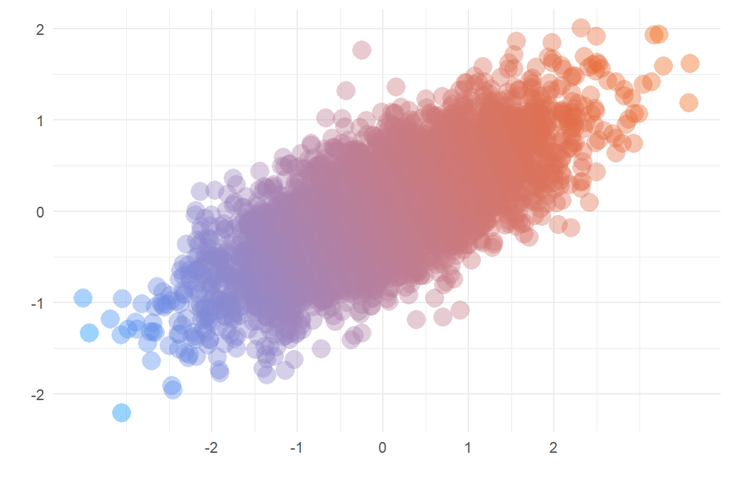

# 3. Teoría de la visualización de datos

Existe una teoría bien fundamentada sobre la visualización de datos ([Ortiz 2014](https://tereom.github.io/est-computacional-2018/)). En este apartado destacamos la contribución pionera de **Edward Tufte** (1942–), estadístico estadounidense y profesor emérito de ciencias políticas, estadística e informática en la Universidad de Yale. Una de las ideas centrales de la obra de Tufte es **eliminar los elementos inútiles** de los gráficos, ya que distraen la atención de los elementos que explican los datos. Acuñó la palabra *chartjunk* («basura gráfica») para referirse a estos elementos inútiles, que no informan o que dificultan la lectura de la información ([Minguillón 2016](http://openaccess.uoc.edu/webapps/o2/handle/10609/57624)). Por el contrario, definió la **excelencia** como la **comunicación de ideas complejas con claridad, precisión y eficiencia** ([Minguillón 2016](http://openaccess.uoc.edu/webapps/o2/handle/10609/57624)).

## 3.1 Indicadores de calidad de un gráfico

Se pueden aplicar a cualquier gráfico. Son guías concretas y relativamente objetivas para evaluar la calidad de un gráfico ([Tufte, 2001](https://www.edwardtufte.com/tufte/books_vdqi)).

- **Integridad gráfica**: lo fielmente que los elementos visuales representan los datos. Hay que minimizar el factor de mentira (cuánto se desvía el gráfico de los datos reales).
- *Chartjunk*: minimizar la decoración gráfica que interfiere en la interpretación de los datos: efecto 3D, tramas…
- **Proporción de tinta de datos**: maximizar la tinta que representa datos respecto a la tinta total usada para imprimir el gráfico.

### 3.1.1 Factor de mentira, *chartjunk* y gráficos de sectores

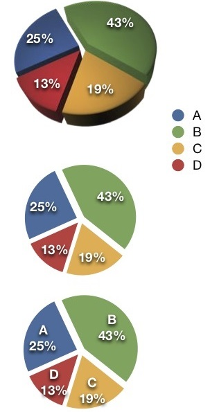

El **factor de mentira** es el cociente entre el tamaño de un efecto tal como se muestra en el gráfico y el tamaño del efecto en los datos. Idealmente, el factor de mentira debería ser 1 (sin distorsión).

El *chartjunk* es cualquier elemento visual innecesario o confuso que no hace falta para entender la información del gráfico, o que distrae a quien lo mira.

### 3.1.2 Proporción de tinta de datos

Maximizar la proporción de **tinta de datos** en nuestros gráficos tiene beneficios inmediatos. La regla es: **si hay tinta que no representa variación en los datos, o si al eliminarla no se pierde significado, esa tinta debe eliminarse**.

$$\text{Proporción de tinta de datos} =
\frac{\text{Tinta que representa datos}}{\text{Tinta total usada para
imprimir el gráfico}}$$

Según el principio de Tufte, ante todo hay que mostrar los datos, así que todo lo que no aporte información debe eliminarse (incluido el color de fondo, los bordes, las cuadrículas…).

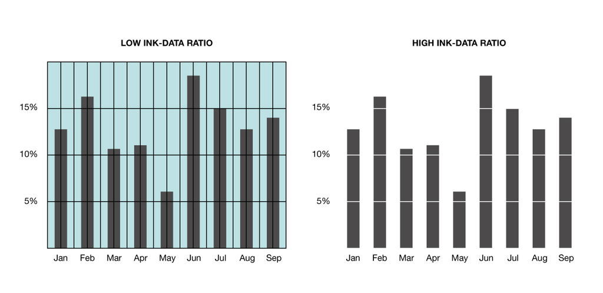

## 3.2 Características de una representación gráfica eficaz

Como hemos visto, Tufte definió la excelencia en la visualización de datos como comunicar ideas complejas con claridad, precisión y eficiencia. Una buena visualización debería:

- Mostrar los datos
- Hacer que quien la mira piense en el contenido, y no en la metodología, el diseño gráfico, la tecnología usada para producirla u otra cosa
- Evitar distorsionar lo que dicen los datos (usar ejes justos, evitar más de un eje `y`)
- Presentar muchos números en poco espacio
- Dar coherencia a conjuntos de datos grandes
- Animar a la vista a comparar distintos datos
- Mostrar los datos a distintos niveles de detalle, desde una visión general hasta la estructura fina
- Tener un propósito razonablemente claro: descripción, exploración, tabulación o decoración
- Estar estrechamente integrada con las descripciones estadísticas y verbales de los datos

# 4. La gramática de gráficos

En un idioma, hay una serie de reglas que organizan las palabras en frases: la gramática. [Wilkinson (2005)](https://www.springer.com/gp/book/9780387245447) creó una gramática de gráficos que nos da los elementos básicos para construirlos.

Los **componentes** (o capas) de la gramática de gráficos son:

- Los **datos** que quieres visualizar
- Un conjunto de **correspondencias estéticas** (`aes`, de *aesthetics*) que describen cómo se asignan las variables de los datos a atributos visuales que podemos percibir (posición, color, tamaño…)
- Las **escalas**, que traducen los valores de los datos a valores del espacio estético (un color, un tamaño o una forma). Las escalas dibujan la leyenda y los ejes, que permiten hacer el camino inverso y leer los valores originales en el gráfico
- Las **transformaciones estadísticas** (`stat`), que resumen los datos de muchas formas útiles. Por ejemplo, agrupar y contar observaciones para crear un histograma, o resumir una relación entre dos variables con un modelo lineal
- Los **objetos geométricos** (`geom`), que representan lo que vemos en el gráfico: puntos, líneas, polígonos, etc.
- Un **sistema de coordenadas** (`coord`), que describe cómo se sitúan las coordenadas de los datos en el plano del gráfico. También proporciona los ejes y las líneas de la cuadrícula para poder leerlo. Normalmente usamos coordenadas cartesianas, pero hay otras, como las coordenadas polares o las proyecciones de mapas
- Las **facetas** (*faceting*), que describen cómo dividir los datos en subconjuntos y mostrarlos como pequeños gráficos múltiples

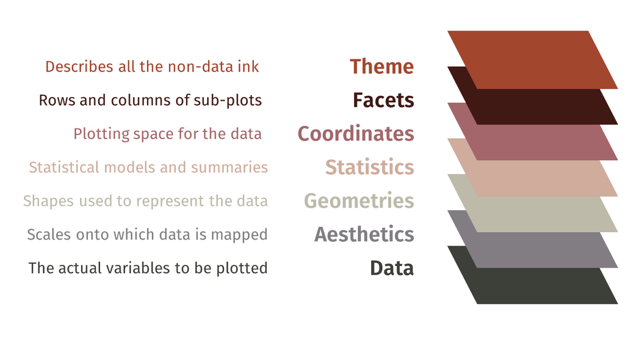

# 5. Primeros pasos con `ggplot2`

Los siguientes ejemplos te guiarán por los componentes básicos de la gramática de `ggplot2`. Usan datos del paquete `datasets`, que ya está cargado por defecto en la sesión de `R`, y algunos conjuntos de datos que se cargan con el paquete `ggplot2`. `ggplot2` necesita que los datos estén guardados en **data frames** y en **formato ordenado** (*tidy*: una observación por fila y una variable por columna):

```r
head(iris)
```

```
##   Sepal.Length Sepal.Width Petal.Length Petal.Width Species
## 1          5.1         3.5          1.4         0.2  setosa
## 2          4.9         3.0          1.4         0.2  setosa
## 3          4.7         3.2          1.3         0.2  setosa
## 4          4.6         3.1          1.5         0.2  setosa
## 5          5.0         3.6          1.4         0.2  setosa
## 6          5.4         3.9          1.7         0.4  setosa
```

```r
class(iris)
```

```
## [1] "data.frame"
```

## Ejemplo 1 | Crear un gráfico de dispersión

### **1a** | Gráfico de dispersión básico

En este primer problema queremos representar la **relación** entre las variables `Sepal.Width` (anchura del sépalo) y `Sepal.Length` (longitud del sépalo) del data frame `iris`. Este data frame es una colección de datos que cuantifica la variación morfológica de las **flores de lirio** (*Iris*) de tres especies emparentadas (*setosa*, *versicolor* y *virginica*).

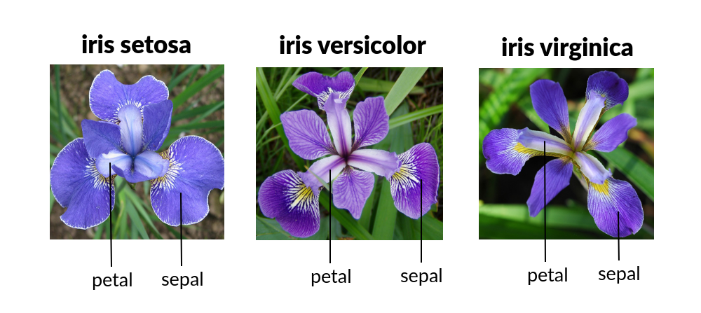

Este famoso conjunto de datos `iris` (de Fisher o de Anderson) contiene las medidas en centímetros de la longitud y la anchura del sépalo y del pétalo de 50 flores de cada una de las 3 especies de lirio. Puedes escribir `??iris` en la consola de `R` para leer una descripción de los datos.

Para representar cualquier gráfico en `ggplot2` necesitamos dos funciones básicas, que se combinan con el signo `+`:

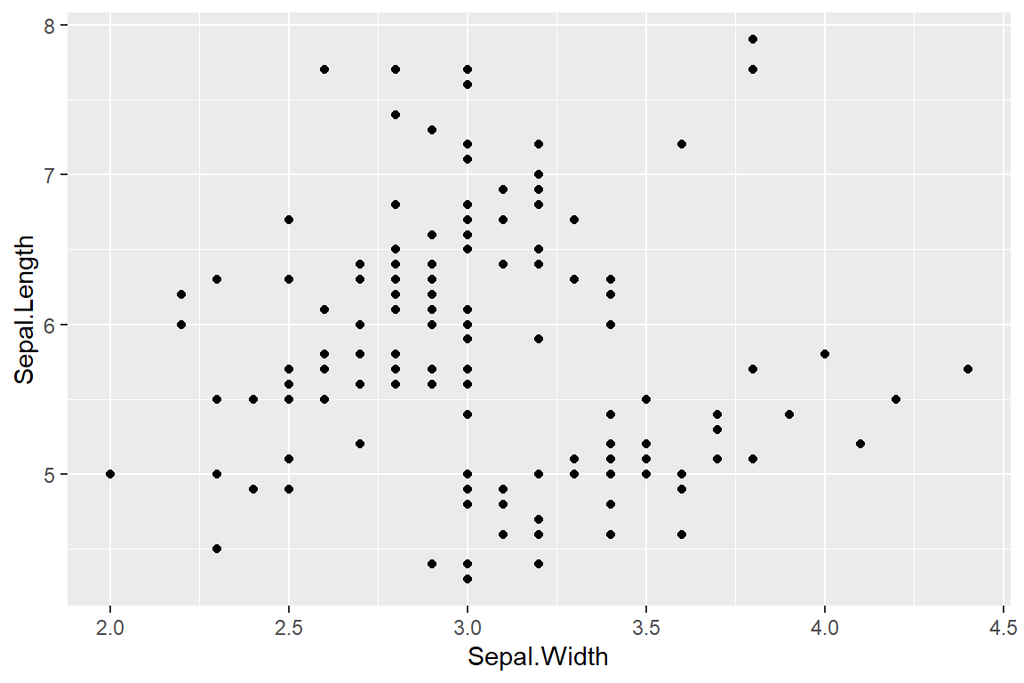

```r
ggplot(data = iris, mapping = aes(x = Sepal.Width, y = Sepal.Length)) +
  geom_point()
```

Las variables que queremos representar van dentro de la función `aes()`, que especifica la *correspondencia* entre las variables y los *atributos estéticos* (en este caso, las posiciones en el espacio, `x` e `y`). Llamamos a las variables directamente por su nombre, porque también le pasamos el data frame entero con el argumento `data`, así que `ggplot` sabe de dónde sacarlas. Por último, añadimos el *objeto geométrico* que queremos representar: en este caso, puntos.

### **1b** | Representar más variables

Otra variable de los datos indica la especie (`Species`) de cada flor. Hay tres especies: *setosa*, *versicolor* y *virginica*.

```r
table(iris$Species)
```

```
##
##     setosa versicolor  virginica
##         50         50         50
```

Supongamos que queremos representar cada especie con un color distinto. En este caso queremos usar `Species` como **variable categórica**, es decir, como factor. Esta variable ya es un factor por defecto:

```r
class(iris$Species)
```

```
## [1] "factor"
```

Usamos `Species` en el atributo estético `colour` (color):

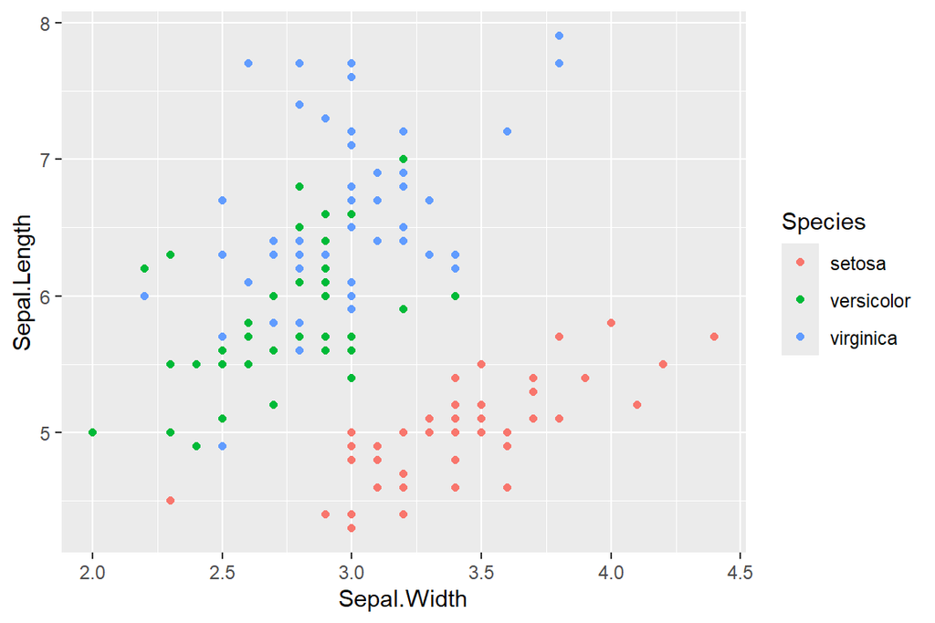

```r
ggplot(data = iris, mapping = aes(x = Sepal.Width, y = Sepal.Length, colour = Species)) +
  geom_point()
```

Fíjate en que `ggplot` añade por defecto una **leyenda** para todas las variables que se han asignado a algún atributo estético. Así podemos leer todas las variables sin esfuerzo adicional.

### Ejercicio

Prueba a asignar `Species` a otro atributo estético en lugar de `colour`, como `shape` (forma), `size` (tamaño) o `alpha` (transparencia). ¿Te aparece algún mensaje de aviso? ¿Por qué?

##### Respuesta:

## **Ejemplo 2** | Crear un gráfico de barras

En este segundo ejercicio vamos a usar el conjunto de datos `mtcars`, que contiene información sobre el **consumo de combustible y 10 aspectos del diseño y el rendimiento de 32 automóviles**.

```r
head(mtcars)
```

```
##                    mpg cyl disp  hp drat    wt  qsec vs am gear carb
## Mazda RX4         21.0   6  160 110 3.90 2.620 16.46  0  1    4    4
## Mazda RX4 Wag     21.0   6  160 110 3.90 2.875 17.02  0  1    4    4
## Datsun 710        22.8   4  108  93 3.85 2.320 18.61  1  1    4    1
## Hornet 4 Drive    21.4   6  258 110 3.08 3.215 19.44  1  0    3    1
## Hornet Sportabout 18.7   8  360 175 3.15 3.440 17.02  0  0    3    2
## Valiant           18.1   6  225 105 2.76 3.460 20.22  1  0    3    1
```

```r
class(mtcars)
```

```
## [1] "data.frame"
```

Los datos proceden de la revista estadounidense Motor Trend de 1974 e incluyen el consumo de combustible y 10 aspectos del diseño y el rendimiento de 32 automóviles (modelos de 1973–74). Puedes escribir `??mtcars` en la consola de `R` para leer una descripción de los datos.

Una de las variables de interés indica el número de cilindros del motor (`cyl`). Hay coches con 4, 6 u 8 cilindros.

### **2a** | Gráfico de barras básico

Queremos resumir estos datos en un **gráfico de barras** sencillo que represente el número de coches de cada categoría de cilindros; es decir, cuántos coches tienen 4, 6 u 8 cilindros. Sin embargo, el número de coches con 4 cilindros, por ejemplo, no es un dato que aparezca en la tabla. Para saberlo habría que contar las filas en las que `cyl = 4`, y no vamos a hacerlo a mano .

`ggplot2` es capaz de hacer operaciones de resumen sencillas con las variables, que llamamos **transformaciones estadísticas**. Una de ellas es contar cuántas veces aparece cada valor de una variable, que es justamente lo que queremos. Y la función `geom_bar` usa por defecto la transformación estadística `count` (contar) sobre la variable asignada al eje `x`.

Lo primero que vamos a hacer es comprobar el tipo de la variable `cyl`:

```r
# Primero comprobamos el tipo de cyl
class(mtcars$cyl)
```

```
## [1] "numeric"
```

Vemos que es una variable numérica. En este caso queremos usar `cyl` como variable categórica, para distinguir grupos y no para indicar un valor en una escala numérica continua. Para ello, tenemos que cambiar su tipo antes de dársela a `ggplot`, con la función `as.factor()`.

```r
# Creamos una nueva variable en el data frame, cyl_f, que es cyl convertida en factor
mtcars$cyl_f <- as.factor(mtcars$cyl)
```

Ahora ya podemos crear el gráfico de barras:

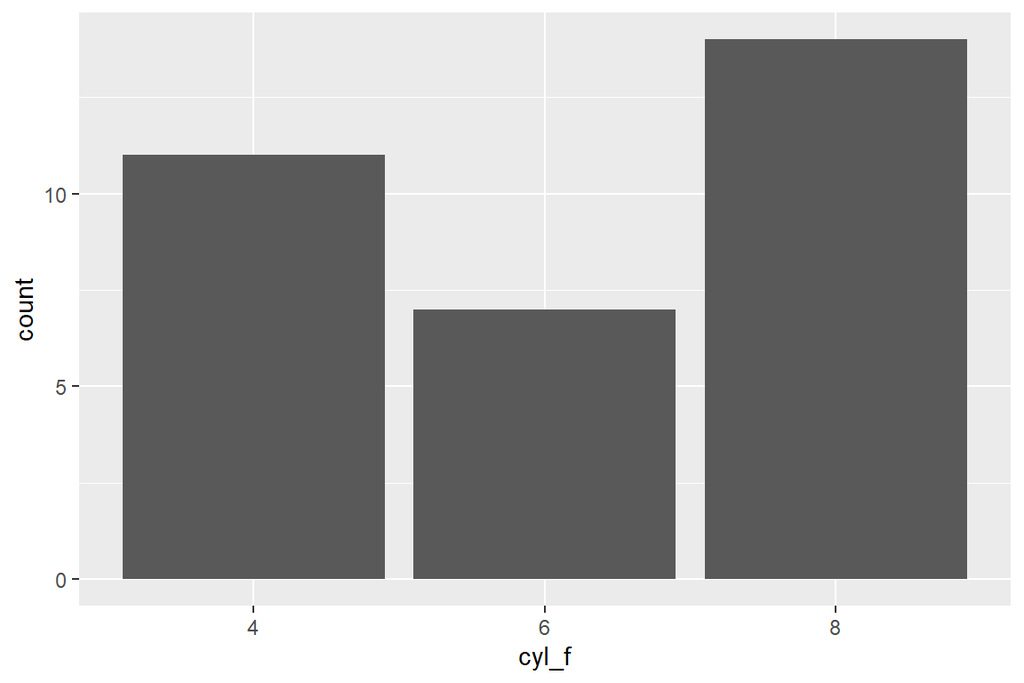

```r
ggplot(data = mtcars, mapping = aes(x = cyl_f)) +
  geom_bar()
```

Imagina que ya tuviéramos una tabla con el número de coches de cada categoría de cilindros. Si tuviéramos un data frame ya calculado con `cyl` y `number_of_cars`, podríamos pasar la variable `number_of_cars` a la función `geom_col` en lugar de `geom_bar`; `geom_col` usa por defecto las variables asignadas a `x` e `y` sin transformarlas.

```r
# Creamos el data frame
counts_by_cyl_data_frame <- as.data.frame(table(mtcars$cyl))
names(counts_by_cyl_data_frame) <- c("cyl", "number_of_cars")

# Vemos el data frame
counts_by_cyl_data_frame
```

```
##   cyl number_of_cars
## 1   4             11
## 2   6              7
## 3   8             14
```

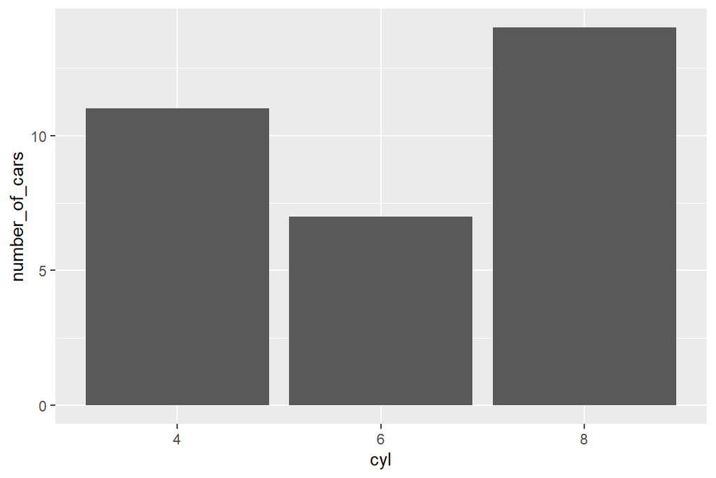

```r
# Nuevo gráfico con geom_col
ggplot(data = counts_by_cyl_data_frame, mapping = aes(x = cyl, y = number_of_cars)) +
  geom_col()
```

Usaremos `geom_bar` si los datos no están procesados y necesitamos contar cuántas veces aparece cada categoría. Si ya tenemos los recuentos calculados, usaremos `geom_col`.

### **2b** | Grupos y posición

En el ejemplo del gráfico de dispersión hemos visto cómo representar con colores los grupos codificados en otras variables. Ahora queremos mostrar en el gráfico de barras el tipo de transmisión (`am`), además del número de cilindros. Podemos asignar `am` al color de relleno de las barras, `fill` (el atributo `colour` cambiaría el borde de los rectángulos). Hay dos tipos de transmisión: `0` para los coches automáticos y `1` para los manuales.

```r
# Primero comprobamos el tipo de la variable
class(mtcars$am)
```

```
## [1] "numeric"
```

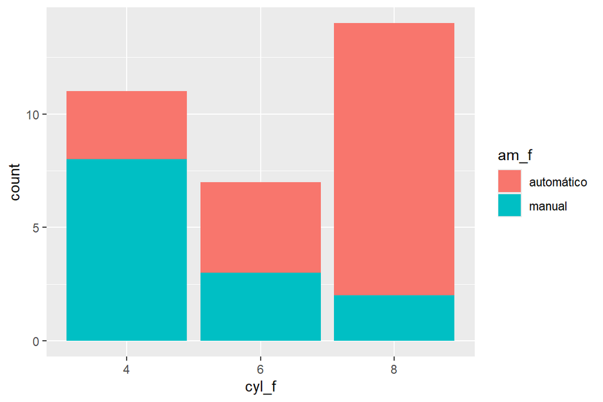

```r
# Convertimos am en factor y cambiamos la notación 0/1 por otra más informativa: automático/manual
mtcars$am_f <- factor(mtcars$am, levels = c(0, 1), labels = c("automático", "manual"))

# Gráfico
ggplot(data = mtcars, mapping = aes(x = cyl_f, fill = am_f)) +
  geom_bar()
```

Cada objeto geométrico de `ggplot2` tiene también un argumento **position** (posición) que controla cómo se colocan los grupos. En `geom_bar`, la posición por defecto es apilar los grupos. Podemos cambiarla para ponerlos uno al lado del otro con `position = "dodge"`.

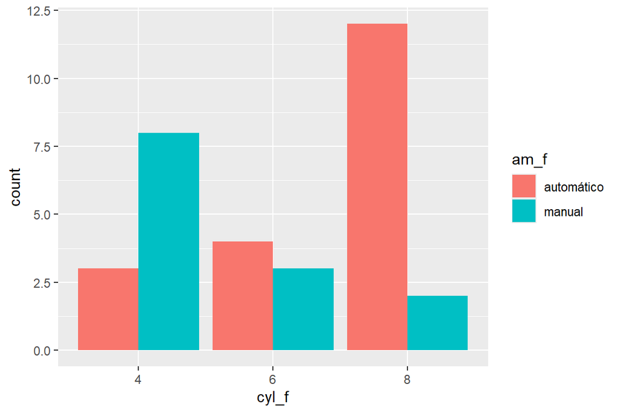

```r
ggplot(data = mtcars, mapping = aes(x = cyl_f, fill = am_f)) +
  geom_bar(position = "dodge")
```

### Ejercicio

Modifica el gráfico anterior usando la posición `"fill"` en lugar de `"dodge"`. ¿Qué hace?

##### Respuesta:

Modifica el gráfico anterior para agrupar por la variable `gear` en lugar de por el tipo de transmisión (`am_f`). La variable `gear` es el número de marchas hacia delante: los coches pueden tener 3, 4 o 5 marchas. Comprueba si hace falta transformar `gear` en un factor.

##### Respuesta:

## **Ejemplo 3** | Mostrar la distribución de una variable: histogramas

### **3a** | Histograma sencillo

Ahora tenemos un conjunto de datos nuevo llamado `diamonds` y necesitamos entender la distribución de algunas de sus variables continuas. Un buen punto de partida es un histograma, que representa con barras el número de observaciones en distintos intervalos.

```r
head(diamonds)
```

```
## # A tibble: 6 × 10
##   carat cut       color clarity depth table price     x     y     z
##   <dbl> <ord>     <ord> <ord>   <dbl> <dbl> <int> <dbl> <dbl> <dbl>
## 1  0.23 Ideal     E     SI2      61.5    55   326  3.95  3.98  2.43
## 2  0.21 Premium   E     SI1      59.8    61   326  3.89  3.84  2.31
## 3  0.23 Good      E     VS1      56.9    65   327  4.05  4.07  2.31
## 4  0.29 Premium   I     VS2      62.4    58   334  4.2   4.23  2.63
## 5  0.31 Good      J     SI2      63.3    58   335  4.34  4.35  2.75
## 6  0.24 Very Good J     VVS2     62.8    57   336  3.94  3.96  2.48
```

```r
class(diamonds)
```

```
## [1] "tbl_df"     "tbl"        "data.frame"
```

`diamonds` es un conjunto de datos con el precio y otros atributos de casi 54.000 diamantes. Puedes escribir `??diamonds` en la consola de `R` para leer una descripción de los datos.

La función que necesitamos se llama `geom_histogram()` y usa por defecto la transformación estadística `bin`. En este caso, `bin` divide la variable asignada a `x` en intervalos y cuenta el número de valores en cada uno. La anchura de los intervalos se controla con el argumento `binwidth`. En este ejemplo mostramos la distribución del peso de los diamantes (`carat`, en quilates).

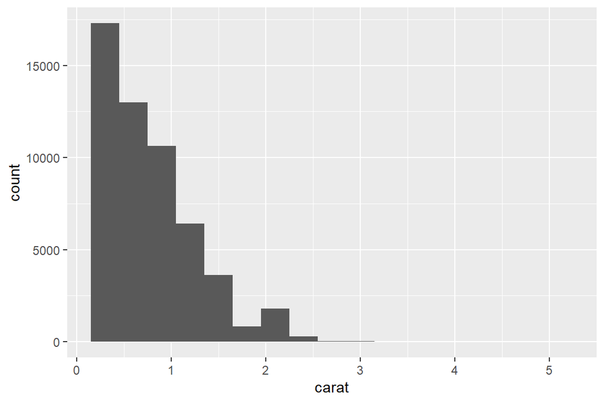

```r
ggplot(data = diamonds, mapping = aes(x = carat)) +
  geom_histogram(binwidth = 0.3)
```

Fíjate en que los histogramas representan variables *continuas*, mientras que los gráficos de barras representan variables *discretas*, aunque a veces se [confunden](https://www.google.com/search?q=diferencia+histograma+gr%C3%A1fico+de+barras).

### **3b** | Varios histogramas

El conjunto de datos `diamonds` contiene más información sobre los diamantes, como la calidad del corte (`cut`) o el color (`color`). Para ver la distribución del peso según el corte, podemos asignar `cut` al relleno (`fill`):

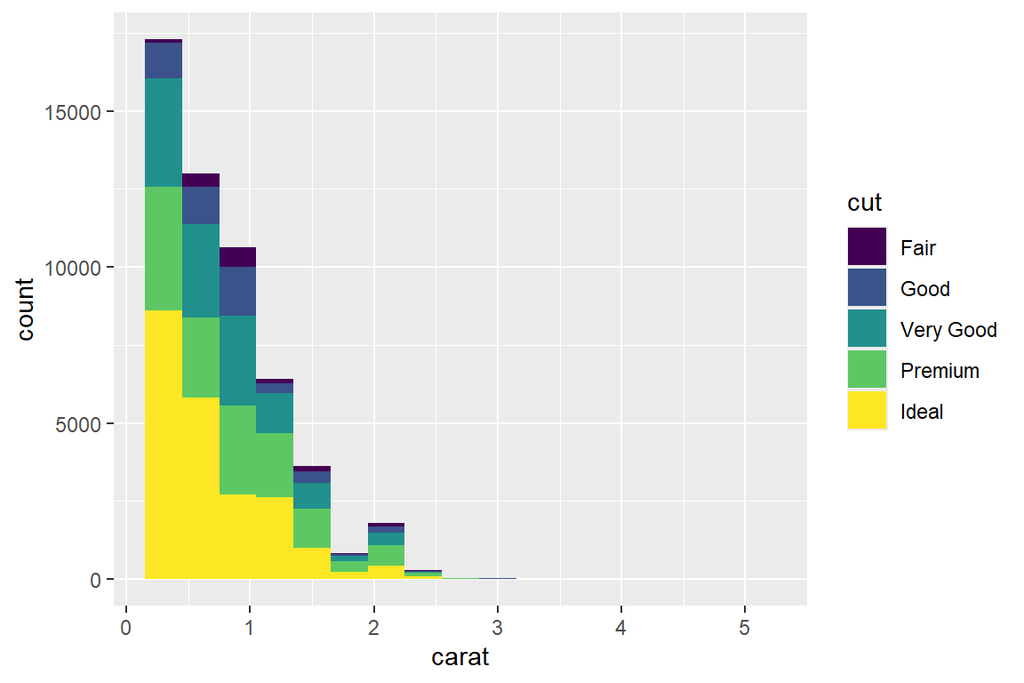

```r
ggplot(data = diamonds, mapping = aes(x = carat, fill = cut)) +
  geom_histogram(binwidth = 0.3)
```

Los histogramas apilados son difíciles de interpretar. Podemos usar otra posición en lugar de la posición por defecto, «apilada» (`"stack"`). Por ejemplo, `position = "dodge"`.

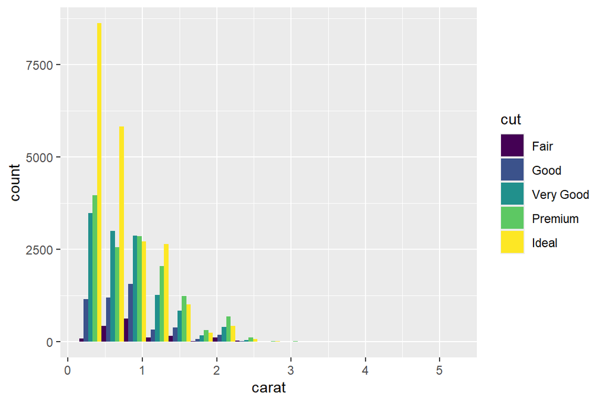

```r
ggplot(data = diamonds, mapping = aes(x = carat, fill = cut)) +
  geom_histogram(position = "dodge", binwidth = 0.3)
```

Pero hay una opción todavía mejor. `ggplot2` permite crear de forma sencilla pequeños gráficos múltiples, o **facetas**, con la función `facet_grid`:

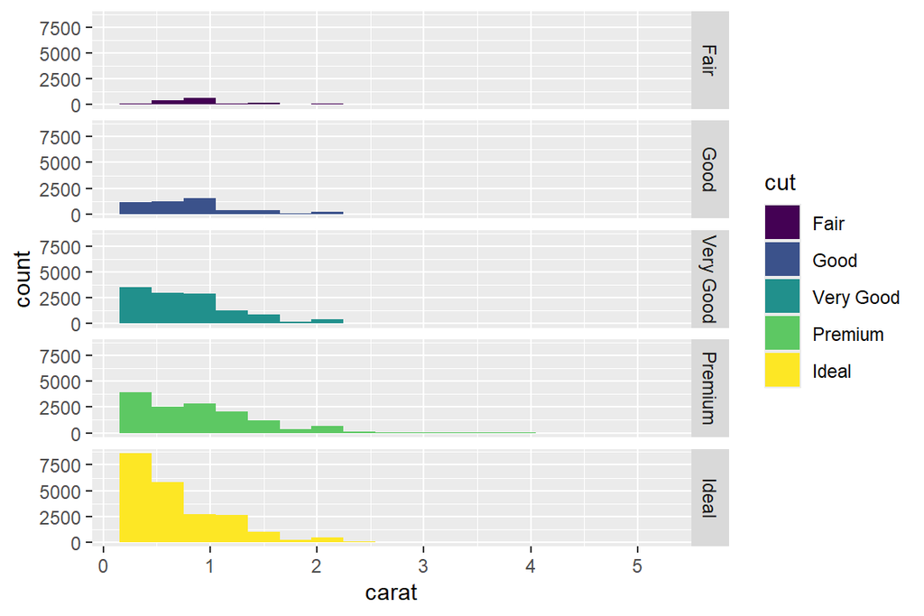

```r
ggplot(data = diamonds, mapping = aes(x = carat, fill = cut)) +
  geom_histogram(position = "dodge", binwidth = 0.3) +
  facet_grid(cut ~ .)
```

### Ejercicio

¿Qué pasa si cambias el orden de los elementos de `facet_grid`, es decir, `(. ~ cut)`?

##### Respuesta:

¿Cuál es la mejor disposición de los subgráficos para comparar las distribuciones? ¿Por qué?

##### Respuesta:

## **Ejemplo 4** | Mostrar la distribución de una variable: diagrama de cajas

### **4a** | Diagrama de cajas sencillo

Otra forma de mostrar la distribución de datos numéricos es un diagrama de cajas (*boxplot*). Permite ver mejor la asimetría, ya que muestra los cuartiles y la mediana de los datos. También muestra los valores atípicos como puntos separados.

La función que vamos a usar es `geom_boxplot()`. En este ejemplo mostramos la distribución del peso de los diamantes (`carat`).

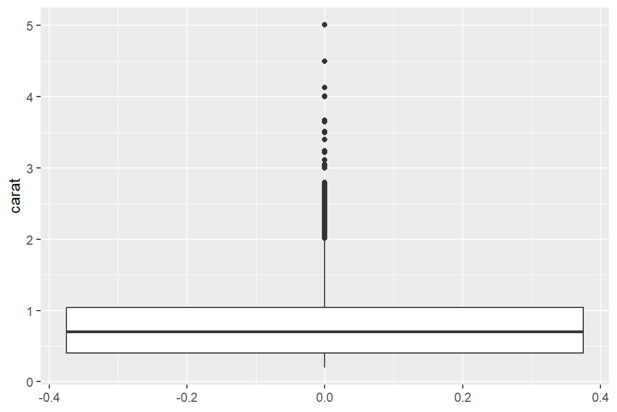

```r
ggplot(data = diamonds, mapping = aes(y = carat)) +
  geom_boxplot()
```

Una característica de los diagramas de cajas es que permiten mostrar la distribución de una variable (`carat`) según otra variable categórica. Por ejemplo, podemos mostrar la distribución de `carat` según el color del diamante (`color`).

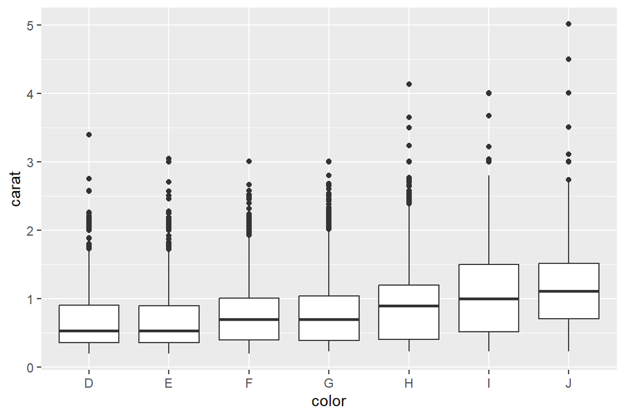

```r
ggplot(data = diamonds, mapping = aes(y = carat, x = color)) +
  geom_boxplot()
```

### Ejercicio

Prueba a rellenar de color las cajas. ¿Cómo lo harías?

##### Respuesta:

## **Ejemplo 5** | Personalizar un gráfico

### **5a** | Cambiar los colores

Hasta ahora hemos usado las **paletas de colores por defecto** en todos los gráficos. Puede que necesitemos cambiarlas para que sean accesibles para las **personas con daltonismo**, para que coincidan con los colores de nuestro proyecto o para darles un **significado** (p. ej., rojo para los valores positivos y azul para los negativos). Podemos controlar con exactitud cómo se asigna una variable a un atributo estético con las funciones `scale_*`.

En el siguiente ejemplo fijamos a mano el color de los cinco tipos de calidad del corte de los diamantes. Puedes usar otros nombres de colores consultando esta [guía de colores de R](http://www.stat.columbia.edu/~tzheng/files/Rcolor.pdf).

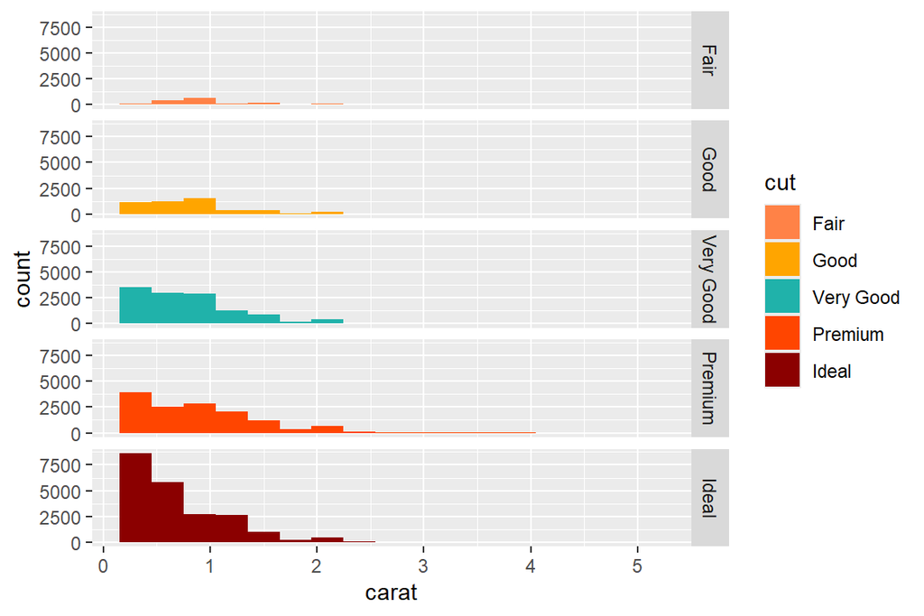

```r
ggplot(data = diamonds, mapping = aes(x = carat, fill = cut)) +
  geom_histogram(position = "dodge", binwidth = 0.3) +
  facet_grid(cut ~ .) +
  scale_fill_manual(values = c("sienna1", "orange", "lightseagreen", "orangered", "red4"))
```

Fíjate en que las funciones de escala cambian a la vez los colores del gráfico y los de la leyenda.

### **5b** | Cambiar (o añadir) los títulos de los ejes, la leyenda y el gráfico

Puede que también necesitemos añadir un **título** al gráfico o cambiar los **títulos de los ejes**. Hay varias opciones:

- En `ggplot2`, los títulos de los ejes y de la leyenda se pueden indicar con el argumento `name` dentro de una función `scale_*`
- El título del gráfico se puede cambiar con `+ ggtitle("Título")`
- También puedes usar la función `labs()`: con `fill = ""` cambias el título de la leyenda y con `title = ""`, el título del gráfico

Mira el ejemplo:

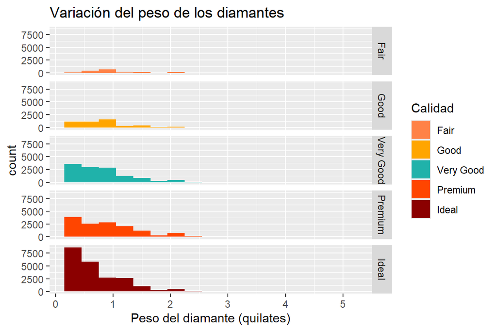

```r
# Guardamos la parte común del gráfico en una variable y después podemos añadir más componentes con el signo "+"
p <- ggplot(data = diamonds, mapping = aes(x = carat, fill = cut)) +
  geom_histogram(position = "dodge", binwidth = 0.3) +
  facet_grid(cut ~ .)

# Opción A:
p + scale_fill_manual(values = c("sienna1", "orange", "lightseagreen", "orangered", "red4"), name = "Calidad") +
  scale_x_continuous(name = "Peso del diamante (quilates)") +
  ggtitle("Variación del peso de los diamantes")
```

```r
# Opción B:
# p + scale_fill_manual(values = c("sienna1", "orange", "lightseagreen", "orangered", "red4")) +
#   labs(title = "Variación del peso de los diamantes", x = "Peso del diamante (quilates)", fill = "Calidad")
```

### **5c** | Cambiar el tema

El aspecto de los gráficos de `ggplot2` se controla con los **temas** (*themes*). El tema por defecto de `ggplot2` tiene el fondo gris y «está diseñado para dar protagonismo a los datos y facilitar las comparaciones». Puedes cambiar el aspecto general eligiendo otro tema con las funciones `theme_*`. Hay [ocho temas distintos](https://ggplot2.tidyverse.org/reference/ggtheme.html) disponibles. El siguiente ejemplo usa el tema «blanco y negro» (`theme_bw()`):

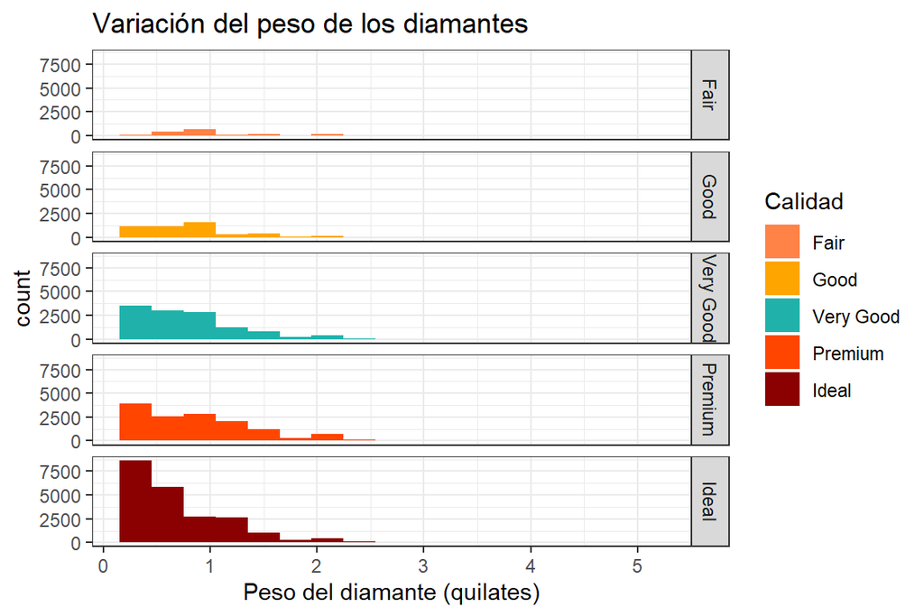

```r
ggplot(data = diamonds, mapping = aes(x = carat, fill = cut)) +
  geom_histogram(position = "dodge", binwidth = 0.3) +
  facet_grid(cut ~ .) +
  scale_fill_manual(values = c("sienna1", "orange", "lightseagreen", "orangered", "red4"), name = "Calidad") +
  scale_x_continuous(name = "Peso del diamante (quilates)") +
  ggtitle("Variación del peso de los diamantes") +
  theme_bw()
```

### Ejercicio

Con el código siguiente, prueba otras funciones `scale_fill_*` de `ggplot2` con paletas predefinidas, como `scale_fill_hue()`, `scale_fill_brewer()`, `scale_fill_viridis_d()` (la que se usa por defecto) y `scale_fill_grey()`. ¿Qué paleta usarías para asegurarte de que las personas con daltonismo distinguen los colores, `scale_fill_hue()` o `scale_fill_viridis_d()`?

##### Respuesta:

Prueba los argumentos `subtitle = ""`, `caption = ""` y `tag = ""` de la función `labs()`. ¿Para qué sirven?

##### Respuesta:

De los [ocho temas disponibles](https://ggplot2.tidyverse.org/reference/ggtheme.html), ¿cuál crees que maximiza la proporción de tinta de datos?

##### Respuesta:

## Guardar los gráficos

Hay varias formas de guardar un gráfico en un archivo. Aquí tienes dos ejemplos:

A. El botón `Export` del panel de gráficos (*Plots*) de `RStudio`:

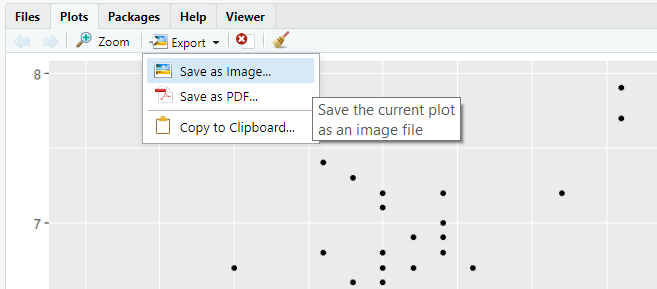

B. La función `ggsave` del paquete `ggplot2`:

```r
p <- ggplot(data = iris, mapping = aes(x = Sepal.Width, y = Sepal.Length)) + geom_point()

ggsave(filename = "grafico.png", plot = p, width = 6, height = 4) # En pulgadas por defecto
```

Los gráficos se pueden guardar en distintos formatos de imagen. La opción **A** te ofrece los formatos en una lista desplegable (PNG, JPG…), y la opción **B** deduce el formato a partir de la extensión del nombre del archivo (p. ej. `grafico.png` o `grafico.pdf`).

Los principales formatos se pueden clasificar en:

- Formatos de mapa de bits (*raster*), en los que la información se guarda en píxeles y tienen una resolución máxima.
  - **PNG**: extensión .png, admite fondo transparente, buena compresión, no pierde calidad
  - **JPEG**: extensiones .jpg y .jpeg, muy buena compresión, se usa en fotografía personal, pero pierde calidad con cada modificación
  - **TIFF**: extensiones .tif y .tiff, formato preferido para la impresión profesional
- Formatos vectoriales, en los que la información se codifica en formas geométricas que se pueden mostrar a cualquier tamaño sin perder resolución.
  - **SVG**: extensión .svg, el estándar de los gráficos vectoriales; necesita el paquete `svglite`
- Híbridos
  - **PDF**: puede contener tanto gráficos vectoriales como imágenes de mapa de bits

### Ejercicio

Guarda el gráfico `p` en un formato de mapa de bits y en uno vectorial, con el mismo tamaño, usando `ggsave()` (p. ej.: `width = 6, height = 4`). ¿Qué diferencias observas al ampliarlos?

Nota: para guardar en SVG necesitas el paquete `svglite` de R (y, en Linux, algunas librerías del sistema). ¡Sáltate el ejercicio si te da error!

##### Respuesta:

## Ejercicio de recapitulación

Si para representar un gráfico de dispersión usamos `geom_point()` y para un gráfico de barras `geom_bar()`… ¿te imaginas cómo representar un gráfico de **líneas** con la sintaxis de `ggplot2`?

- Representa cómo cambia la variable `unemploy` (número de personas desempleadas, en miles) a lo largo del tiempo (variable `date`) del conjunto de datos `economics` con un gráfico de líneas, usando la sintaxis de `ggplot2`
- Cambia los nombres de los ejes y añade un título
- Usa un tema
- Guarda el gráfico en un archivo con un formato de mapa de bits (png)

##### Respuesta:

La imagen final debería parecerse a esta:

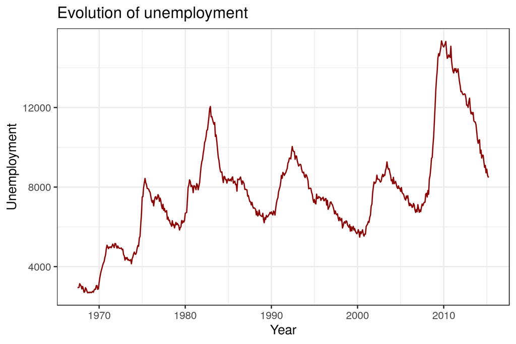